# hw#4.data624

Sang Yoon (Andy) Hwang

September 22, 2019

# 7.8 Exercises

# 7.8.1. Consider the `pigs` series - the number of pigs slaughtered in Victoria each month.

# a. Use the ses() function in R to find the optimal values of alpha and l0 and generate forecasts for the next four months.

From `summary(fc)`, we know that alpha = 0.2971 and l0 = 77260.06. For n the forcasts for the next 4 months, we see that it has a “flat” forecast of 98816.41.

```r
fc <- ses(pigs, h = 4)
fc
```

```
##          Point Forecast    Lo 80    Hi 80    Lo 95    Hi 95
## Sep 1995       98816.41 85605.43 112027.4 78611.97 119020.8
## Oct 1995       98816.41 85034.52 112598.3 77738.83 119894.0
## Nov 1995       98816.41 84486.34 113146.5 76900.46 120732.4
## Dec 1995       98816.41 83958.37 113674.4 76092.99 121539.8
```

```r
#fitted(fc)
summary(fc)
```

```
##
## Forecast method: Simple exponential smoothing
##
## Model Information:
## Simple exponential smoothing
##
## Call:
##  ses(y = pigs, h = 4)
##
##   Smoothing parameters:
##     alpha = 0.2971
##
##   Initial states:
##     l = 77260.0561
##
##   sigma:  10308.58
##
##      AIC     AICc      BIC
## 4462.955 4463.086 4472.665
##
## Error measures:
##                    ME    RMSE      MAE       MPE     MAPE      MASE
## Training set 385.8721 10253.6 7961.383 -0.922652 9.274016 0.7966249
##                    ACF1
## Training set 0.01282239
##
## Forecasts:
##          Point Forecast    Lo 80    Hi 80    Lo 95    Hi 95
## Sep 1995       98816.41 85605.43 112027.4 78611.97 119020.8
## Oct 1995       98816.41 85034.52 112598.3 77738.83 119894.0
## Nov 1995       98816.41 84486.34 113146.5 76900.46 120732.4
## Dec 1995       98816.41 83958.37 113674.4 76092.99 121539.8
```

# b. Compute a 95% prediction interval for the first forecast using y_^1.96s where s is the standard deviation of the residuals. Compare your interval with the interval produced by R.

```r
lo95 = fc$mean[1] - (sd(fc$residuals) * 1.96)
hi95 = fc$mean[1] + (sd(fc$residuals) * 1.96)

lo95
```

```
## [1] 78679.97
```

```r
hi95
```

```
## [1] 118952.8
```

```r
fc
```

```
##          Point Forecast    Lo 80    Hi 80    Lo 95    Hi 95
## Sep 1995       98816.41 85605.43 112027.4 78611.97 119020.8
## Oct 1995       98816.41 85034.52 112598.3 77738.83 119894.0
## Nov 1995       98816.41 84486.34 113146.5 76900.46 120732.4
## Dec 1995       98816.41 83958.37 113674.4 76092.99 121539.8
```

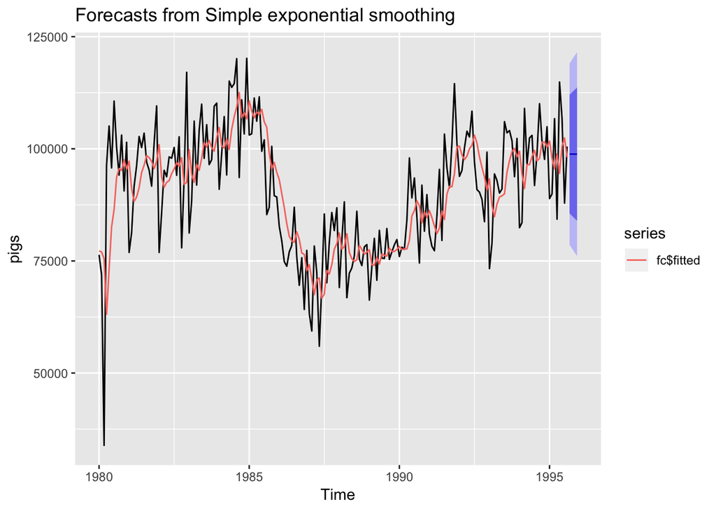

```r
# plot the data with fitted values to forcast
autoplot(fc) + autolayer(fc$fitted)
```

# 7.8.3 Modify your function from the previous exercise to return the sum of squared errors rather than the forecast of the next observation. Then use the `optim()` function to find the optimal values of alpha and l0. Do you get the same values as the `ses()` function?

The results are almost the same but not exactly the same. I think this is due to the scale difference in alpha and l0 when it comes to calculation.

```r
# create ses function manually to test forecasted value
ses_manual <- function(y, alpha, l0){
  y_hat <- l0
  for(index in 1:length(y)){
   y_hat <- alpha*y[index] + (1 - alpha)*y_hat
  }
  cat("Forecast result by ses_optim function: ",
      as.character(y_hat),
      sep = "\n")
}

# Let's compare the forecasting results from built-in SES function in R to manual function using optim
a <- fc$model$par[1]
l0 <- fc$model$par[2]

# They are the same!
ses_manual(pigs, alpha = a, l0 = l0)
```

```
## Forecast result by ses_optim function:
## 98816.4061115907
```

```r
cat("Forecast result by built-in ses function: ", fc$mean[1], sep = "\n")
```

```
## Forecast result by built-in ses function:
## 98816.41
```

```r
# now, let's change the above function to get alpha and l0
ses_param <- function(pars = c(alpha, l0), y){
  error <- 0
  SSE <- 0
  alpha <- pars[1]
  l0 <- pars[2]
  y_hat <- l0

  for(index in 1:length(y)){
    error <- y[index] - y_hat
    SSE <- SSE + error^2

    y_hat <- alpha*y[index] + (1 - alpha)*y_hat
  }

  return(SSE)
}

# Let's compare the results for alphan and l0 from built-in SES function in R to manual function using optim
optim_param <- optim(par = c(0.5, pigs[1]), y = pigs, fn = ses_param)

# Almost same
cat("Parameters estimate by manual ses_param function: ", optim_param$par[1], optim_param$par[2], sep = "\n")
```

```
## Parameters estimate by manual ses_param function:
## 0.2990081
## 76379.27
```

```r
cat("Parameters estimate by built-in ses function: ", fc$model$par[1], fc$model$par[2])
```

```
## Parameters estimate by built-in ses function:  0.2971488 77260.06
```